# Assignment 3

## Submit as an HTML file

Print your Emory ID below

```python
print(str(2670867))
```

```
2670867
```

Import the numpy and matplotlib packages

```python
# Write your own code
import pandas as pd
import numpy as np
import matplotlib.pyplot as plt
```

(a) Compute a formula:

$V=P\left(1+{\frac {r}{n}}\right)^{nt}$

Calculate $V$ when:

- $P = 1800 $
- $r = 0.24$
- $n = 12$
- $t = 8$

To get full points:

- First define each of these variables
- Write the formula above

```python
# Note (if you're interested in the context)
# V = Accumulated value of investment
# P = Principal (the amount deposited)
# r = Quarterly interest rate
# n = Number of months in a year
# t = Number of years

# Write your own code
def myfunction(P,r,n,t):
    V = P*(1+(r/n))**(n*t)
    print(V)

myfunction(1800,0.24,12,8)
```

```
12047.27972315071
```

(b) Composite operations on arrays

- Define $r = 0.06$
- Define two arrays $a$ and $t$ using "np.array()", assigning the following values

$ a = \begin{pmatrix} a_0 \\ a_1 \\ a_2 \end{pmatrix} = \begin{pmatrix} 20 \\ 30 \\ 15 \end{pmatrix}, \qquad t = \begin{pmatrix} t_0 \\ t_1 \\ t_2 \end{pmatrix} = \begin{pmatrix} 0 \\ 1 \\ 2 \end{pmatrix} $

- Use element-by-element vector operations to compute a new array $M$ of length 3:

$ M = \begin{pmatrix} a_0 / (1+r)^{t_0} \\ a_1 / (1+r)^{t_1} \\ a_2 / (1+r)^{t_2} \end{pmatrix} $

- Compute the sum of the values of $M$ using "M.sum()"

Note: I am using subscripts to denote the individual elements of $a$ and $t$.

- In the code just enter the values of $a$ and $t$.
- To get full points you must do all of the above tasks

```python
# Write your own code
r = 0.06
a = np.array([20, 30, 15])
print(a)
t = np.array([0, 1, 2])
print(t)
M = np.array([(a/(1+r))**(t)])
column_sums = M.sum(axis=0) # axis=0 specifies that the sum should be computed down the rows for each column.

print(f"[{column_sums[0]:.2f}, {column_sums[1]:.2f}, {column_sums[2]:.2f}]")
 #format the value of M[0,0] as a floating-point number with exactly 2 digits after the decimal point.
```

```
[20 30 15]
[0 1 2]
[1.00, 28.30, 200.25]
```

(c) Plot a normal random variable

To get full points:

- Set a seed using "np.random.seed()"
- Create the random variable with the following parameters
- mean = 3.5, standard deviation = 1.5, and size = 1500
- Create a histogram
- Label the axes

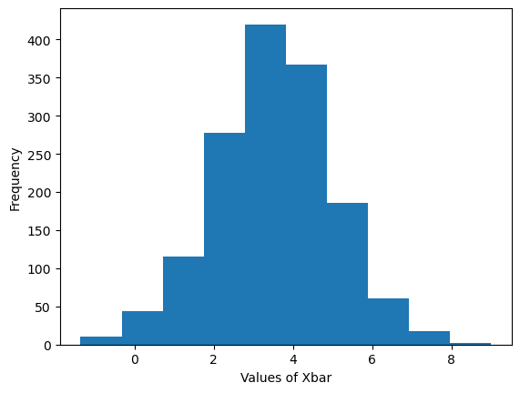

```python
# Write your own code

np.random.seed(151)

mean = 3.5
stan_devia = 1.5
size = 1500

random_variable = np.random.normal(mean, stan_devia, size)
plt.ylabel("Frequency")
plt.xlabel("Values of Xbar")
plt.hist(random_variable)
plt.show()
```

(d) Checking whether word is part of list

- Define a variable "animal" with the value "dog"
- Define a list of animals with the values list_animals = ["cat","rabbit","dog"]
- Write an expression to test whether "animal" is contained in "list_animals"

Hint: Use the "in" command. The final output should be True/False.

To get full points run all of the above commands

```python
# Write your own code
animal = "dog"
list_animals = ["cat","raddit","dog"]
contained = animal in list_animals
print(contained)
```

```
True
```

(e) Classifying a variable

- Define a new variable "temperature" and assign it "25"
- Write an if/else statement that does the following
  - Prints "Temperature below 15" if the temperature is less than or equal to 15.
  - Prints "Temperature between 15 and 20" if the temperature is strictly greater

  than 15 and less than or equal to 20.
  - Prints "Temperature above 20" if the temperature is strictly higher than 20.

To get full points you must do all of the above instructions

```python
# Write your own code
temperature = 25

if temperature > 20:
    print("Temperature above 20")
elif temperature <= 20 & temperature > 15:
    print("Temperature between 15 and 20")
else:
    print("Temperature below 15")
```

```
Temperature above 20
```